# Statistisches Consulting

Waldinventur

Vincent Grunert

7/16/2020

# 1 Einleitung

In dieser Arbeit wird die Prognoseguete verschiedener parametrischer- und nichtparametrischer Modelle zur Schaetzung von Waldinventurdaten verglichen. Zielgroessen (abhaengige-), wie auch erklaerende (unabhaengige) Variablen sind im Datensatz Waldinventurdaten enthalten.

Neben dem vergleich der Prognoseguete wird ebenfalls untersucht ob Cluster, in denen Daten erhoben werden, einen Einfluss auf die zu schaetzenden Zielgroessen haben.

# 2 Literatur

Waldinventur beschaeftigt sich primaer mit der systematischen Datenerfassung- und auswertung von Waldinformationen. Zur Erhebung von Waldinventurdaten bestuende grundsatzlich die Moeglichkeit jeden Baum in einer Region anhand bestimmter Merkmale, z.B. Baumhoehe, Baselflaeche zu beschreiben. Aufgrund der Masse von Baeumen, Abgelegenheit bestimmter Waldbegiete, Personalmangel in der Forstwirtschaft sowie naturbedingter Wachstums- und sterberaten von Baeumen ist dies praktisch nicht umsetzbar.

Aufgrund desssen wurde traditionell zur Erfassung von Waldinventurdaten auf statistische Stichprobenverfahren (Spurr (1952)) zurueckgegriffen. Eine aktuelle Uebersicht zu den verschiedenen Stichprobenverfahren gibt es von McRoberts et al. McRoberts, Tomppo, and Czaplewski (n.d.).

Aufgrund neuer Entwicklungen im Bereich digitaler Messverfahren werden zusaetzlich zu den statistischen Stichprobenverfahren auch vermehrt auf “Light and Radar” (Licht und Radar, kurz: LIDAR) und oder “Enhanced Thematic Mapper” (Verbesserter Thermatischer Zuordner, kurz: ETM) Technologien gesetzt (Peterson et al. (2007), Meng, Cieszewski, and Madden (2009), Lefsky et al. (1999)). Die Kombination aus digitalen Messgeraeten und gesteuerten Flugobjekten (Flugzeuge, Helikopter und Drohnen) ermoeglicht ein umfangreiches Erfassen von Waldinventurdaten.

# 3 Daten

Der urspruengliche Datensatz besteht aus 397 Beobachtungen von 18 Variablen. Von diesen 18 sind vier (4) abhaengige und vierzehn (14) unabhaengige Variablen. In 19 Faellen gibt es fuer die abhaengigen Variablen keine Messungen. Diese Beobachtungen werden aus dem Datensatz entfernt.

Fuer die weitere Analyse werden ausschliesslich 378 Bebachtungen herangezogen. In den folgenden Tabellen befindet sich jeweils in der ersten Zeile eine Statistik und in der zweiten Zeile darunter das dazugehoerige 95% Konfidenzintervall. Fuer alle Messbaren Variablen werden insgesamt sechs (6) Statistiken angegeben: Minimum, erste Quantil (Q1), Mittelwert, Median, dritte Quantil und Maximum. Anhand dieser Statistiken wird eine Aussage ueber moegliche Ausreisser in den Beobachtungen gemacht. Die Differenz (Q3 - Q1) wird als Interquantilsabstand (IQA) bezeichnet. Eine Beobachtung (X) wird gem. folgender Formel als Ausreisser klassifiziert:

- X - 1.5 * IQA + Q3 > 0 (Ausreisser nach oben) oder
- Q1 - 1.5 * IQA - X > 0 (Ausreisser nach unten)

Folglich gilt fuer beide Ungleichungen dass positive Werte nach dieser Regel als Ausreisser klassifiziert werden und negative nicht.

## 3.1 Abhaengige Variablen

Es gibt vier (4) abhaengige Variablen in diesem Datensatz.

- **vorratha**: Stammholzvorrat pro Hektar (gemessen in m3/ha)

|  | Min | Q1 | Mean | Median | Q3 | Max |
| --- | --- | --- | --- | --- | --- | --- |
| vorratha | 6.24 | 197.15 | 382.29 | 340.52 | 532.79 | 1144.35 |
| KI | NA | 168.4 , 218 | 358.77 , 405.82 | 312.45 , 364.56 | 499.24 , 564.19 | NA |

Tabelle 1: Statistische Zusammenfassung von Stammholzvorrat pro Hektar.

Der IQA betraegt: 335.64. Das Maximum ist ein Ausreisser: 1144.35 - 1.5 * 335.64 - 532.79 = 108.1. Somit existiert mindestens ein Ausreisser nach oben. Das Minimum ist kein Ausreisser: 197.15 - 1.5 * 335.64 - 6.24 = -312.55 und somit auch kein Wert der groesser ist als das Minimum.

- **gha**: Basalflaeche pro Hektar (Baumstammquerschnittsflaeche)

|  | Min | Q1 | Mean | Median | Q3 | Max |
| --- | --- | --- | --- | --- | --- | --- |
| vgha | 0 | 24.92 | 40.4 | 38.42 | 54.15 | 120.68 |
| KI | NA | 22.2 , 27.2 | 38.27 , 42.52 | 35.2 , 40.56 | 51.37 , 57.63 | NA |

Tabelle 2: Statistische Zusammenfassung von Basalflaeche pro Hektar.

Der IQA betraegt: 29.23. Das Maximum ist ein Ausreisser: 120.68 - 1.5 * 29.23 - 54.15 = 22.685. Somit existiert mindestens ein Ausreisser nach oben. Das Minimum ist kein Ausreisser: 24.92 - 1.5 * 29.23 - 0 = -18.925 und somit auch kein Wert der groesser ist als das Minimum.

- **stzha**: Stammzahl pro Hektar (alle Baeume)

|  | Min | Q1 | Mean | Median | Q3 | Max |
| --- | --- | --- | --- | --- | --- | --- |
| stzha | 0 | 307.11 | 1019.65 | 628 | 1364.91 | 7979.24 |
| KI | NA | 257.9 , 350.3 | 905.81 , 1124.04 | 528.77 , 693.57 | 1259.72 , 1545.45 | NA |

Tabelle 3: Statistische Zusammenfassung von Stammzahl pro Hektar (alle Baeume).

Der IQA betraegt: 1057.8. Das Maximum ist ein Ausreisser: 7979.24 - 1.5 * 1057.8 - 1364.91 = 5027.63. Somit existiert mindestens ein Ausreisser nach oben. Das Minimum ist kein Ausreisser: 307.11 - 1.5 * 1057.8 - 0 = -1279.59 und somit auch kein Wert der groesser ist als das Minimum.

- **stzha105**: Stammzahl pro Hektar (Baeume ab 105mm Durchmesser)

|  | Min | Q1 | Mean | Median | Q3 | Max |
| --- | --- | --- | --- | --- | --- | --- |
| stzha105 | 0 | 260.45 | 648.34 | 509.34 | 898 | 2660.29 |
| KI | NA | 219.4 , 289.3 | 594.57 , 699.73 | 454.87 , 577.07 | 807.5 , 993.95 | NA |

Tabelle 4: Statistische Zusammenfassung von Stammzahl pro Hektar (Baeume ab 105mm Durchmesser).

Der IQA betraegt: 637.55. Das Maximum ist ein Ausreisser: 2660.29 - 1.5 * 637.55 - 898 = 805.965. Somit existiert mindestens ein Ausreisser nach oben. Das Minimum ist kein Ausreisser: 260.45 - 1.5 * 637.55 - 0 = -695.875 und somit auch kein Wert der groesser ist als das Minimum.

Die Konfidenzintervalle der jeweiligen Schaetzer wurden mittels empirischem Bootstrap mit 10tsd bootstrap Stichproben geschaetzt. Fuer die das Minimum und Maximum ist das bootstrap Verfahren nicht anwendbar. Aus diesem Grund wurde an dieser Stelle auf eine Schaetzung des Konfidenzintervalls fuer diese Statistiken verzichtet.

Figur 1 gibt die Boxplots der abhaengigigen Variablen wieder. Die Punkte in den Boxplots sind Beobachtungen die absolut weiter wie 1.5 mal dem Interquantisabstand vom Q3 oder Q1 entfernt sind. Die Boxplots bestaetigen die bereits gemachten Aussagen: Alle Zielgroessen weisen mindestens zwei Ausreisser nach oben auf.

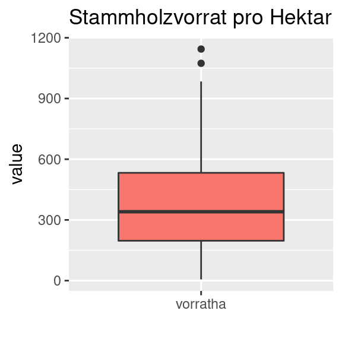

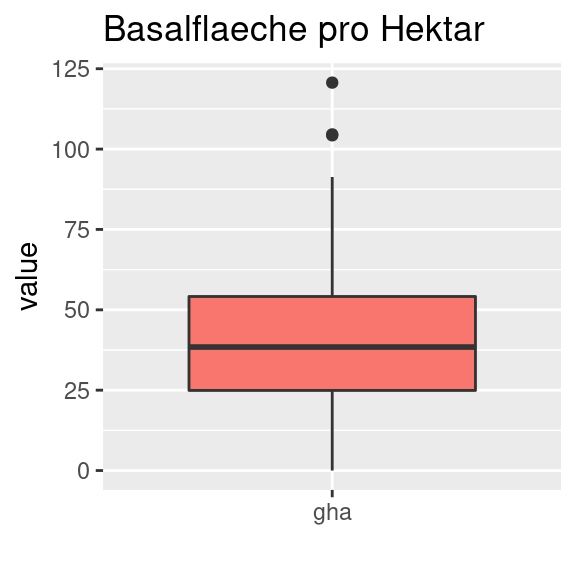

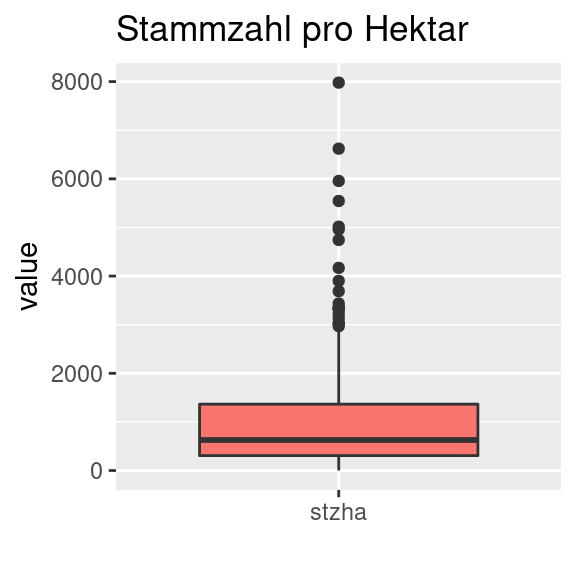

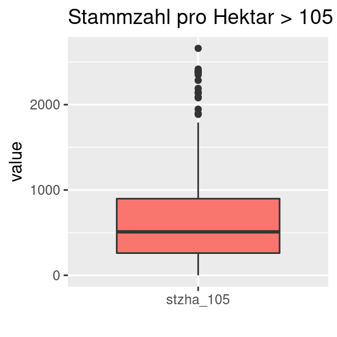

Figur 1: Boxplot der Abhaengigen Variablen

## 3.2 Unabhaengige Variablen

Es gibt insgesat vierzehn (14) unabhaengige Variablen. Von diesen vierzehn (14) sind zehn (10) metrisch und vier (4) kategorisch.

### 3.2.1 Metrische Variablen

Die metrischen Variablen im Datensatz sind:

- **shstufe**: Seehoehe (in 100 m Stufen). In hohen Seehoehen liegen die Aeste enger am Stamm an und der Vorrat ist entsprechend hoeher zu schaetzen.

|  | Min | Q1 | Mean | Median | Q3 | Max |
| --- | --- | --- | --- | --- | --- | --- |
| shstufe | 1 | 5 | 8.061 | 8 | 11 | 19 |
| KI | NA | 5 , 6 | 7.68 , 8.46 | 7.5 , 9 | 11 , 12 | NA |

Tabelle 5: Statistische Zusammenfassung von Seehoehe.

Der IQA betraegt: 6. Das Maximum ist kein Ausreisser nach oben: 19 - 1.5 * 6 - 11 = -1 und folglich auch kein Wert der kleiner ist. Das Minimum ist kein Ausreisser nach unten: 5 - 1.5 * 6 - 1 = -5 und somit auch kein Wert der groesser ist.

- **mittvegh**: Mittlere Vegetationshoehe (in m)

|  | Min | Q1 | Mean | Median | Q3 | Max |
| --- | --- | --- | --- | --- | --- | --- |
| mittvegh | 0.004 | 12.278 | 18.01 | 18.385 | 23.842 | 36.255 |
| KI | NA | 11.2 , 13.3 | 17.23 , 18.81 | 17.09 , 19.7 | 22.62 , 24.92 | NA |

Tabelle 6: Statistische Zusammenfassung von Mittlere Vegetationshoehe.

Der IQA betraegt: 11.56. Das Maximum ist kein Ausreisser nach oben: 36.26 - 1.5 * 11.56 - 23.84 = -4.93 und folglich auch kein Wert der kleiner ist. Das Minimum ist kein Ausreisser nach unten: 12.28 - 1.5 * 11.56 - 0 = -5.07 und somit auch kein Wert der groesser ist.

- **hmax**: Maximale Vegetationshoehe (in m)

|  | Min | Q1 | Mean | Median | Q3 | Max |
| --- | --- | --- | --- | --- | --- | --- |
| hmax | 0.19 | 22.133 | 28.78 | 28.678 | 34.397 | 60 |
| KI | NA | 20.9 , 23.6 | 27.72 , 29.81 | 27.22 , 29.89 | 33.67 , 35.43 | NA |

Tabelle 7: Statistische Zusammenfassung von Maximale Vegetationshoehe.

Der IQA betraegt: 12.26. Das Maximum ist ein Ausreisser nach oben: 60 - 1.5 * 12.26 - 34.4 = 7.21 und folglich existiert mindestens ein Ausreisser nach oben. Das Minimum ist ein Ausreisser nach unten: 22.13 - 1.5 * 12.26 - 0.19 = 3.55 und existiert mindestens ein Ausreisser nach unten.

- **hmin**: Minimale Vegetationshoehe (in m)

|  | Min | Q1 | Mean | Median | Q3 | Max |
| --- | --- | --- | --- | --- | --- | --- |
| hmin | 0 | 0.073 | 6.392 | 1.519 | 12.74 | 30.262 |
| KI | NA | 0 , 0.1 | 5.6 , 7.16 | -0.23 , 2.27 | 11.03 , 15.06 | NA |

Tabelle 8: Statistische Zusammenfassung von Minimale Vegetationshoehe.

Der IQA betraegt: 12.67. Das Maximum ist kein Ausreisser nach oben: 30.26 - 1.5 * 12.67 - 12.74 = -1.48 und folglich auch kein Wert der kleiner ist. Das Minimum ist kein Ausreisser nach unten: 0.07 - 1.5 * 12.67 - 0 = -18.93 und somit auch kein Wert der groesser ist.

- **npeaks**: Anzahl der lokalen Maxima (höher als die 8 anliegenden Pixel)

|  | Min | Q1 | Mean | Median | Q3 | Max |
| --- | --- | --- | --- | --- | --- | --- |
| npeaks | 0 | 13 | 15.362 | 16 | 18 | 28 |
| KI | NA | 12 , 14 | 14.95 , 15.79 | 16 , 17 | 17 , 18 | NA |

Tabelle 9: Statistische Zusammenfassung von Anzahl der lokalen Maxima.

Der IQA betraegt: 5. Das Maximum ist ein Ausreisser nach oben: 28 - 1.5 * 5 - 18 = 2.5 und folglich existiert mindestens ein Ausreisser nach oben. Das Minimum ist ein Ausreisser nach unten: 13 - 1.5 * 5 - 0 = 5.5 und somit existiert mindestens ein Ausreisser nach unten.

- **sdbins**: Die Rauhigkeit der Vegetation in Form der Standardabweichung der Hoehen

|  | Min | Q1 | Mean | Median | Q3 | Max |
| --- | --- | --- | --- | --- | --- | --- |
| sdbins | 0.019 | 2.551 | 4.695 | 4.08 | 6.669 | 13.837 |
| KI | NA | 2.3 , 2.8 | 4.41 , 4.96 | 3.73 , 4.44 | 6.26 , 7.47 | NA |

Tabelle 10: Statistische Zusammenfassung von Rauhigkeit der Vegetation.

Der IQA betraegt: 4.12. Das Maximum ist ein Ausreisser nach oben: 13.84 - 1.5 * 4.12 - 6.67 = 0.99 und folglich existiert mindestens ein Ausreisser nach oben. Das Minimum ist kein Ausreisser nach unten: 2.55 - 1.5 * 4.12 - 0.02 = -3.64 und somit auch kein Wert der groesser ist.

- **zw10u20**: Die Anzahl der Pixel zwischen 10 und 20 m Hoehe, relevant für die Stammzahl. Da es viele kleine und wenig große Baeume gibt, haben zu hohe Pixel keinen Einfluss auf die Stammzahl. Zu kleine Baeume sieht man nicht.

|  | Min | Q1 | Mean | Median | Q3 | Max |
| --- | --- | --- | --- | --- | --- | --- |
| zw10u20 | 0 | 18 | 102.439 | 76 | 171.5 | 316 |
| KI | NA | 14 , 27 | 92.66 , 112.21 | 64 , 93 | 150 , 195.5 | NA |

Tabelle 11: Statistische Zusammenfassung von Anzahl der Pixel zwischen 10 und 20 m Hoehe.

Der IQA betraegt: 153.5. Das Maximum ist kein Ausreisser nach oben: 316 - 1.5 * 153.5 - 171.5 = -85.75 und folglich auch kein Wert der kleiner ist. Das Minimum ist kein Ausreisser nach unten: 18 - 1.5 * 153.5 - 0 = -212.25 und somit auch kein Wert der groesser ist.

- **nh_ok, ki, lh**: Baumartenanteile Nadelholz ohne Kiefer, Kiefer, Laubholz. Summer ergibt 1. Konfidenzintervalle sind fuer diese Daten nicht aussagekraeftig und werden aus diesem Grund nicht angegeben.

|  | Min | Q1 | Mean | Median | Q3 | Max |
| --- | --- | --- | --- | --- | --- | --- |
| nh_ok | 0 | 0.409 | 0.689 | 0.87 | 1 | 1 |
| ki | 0 | 0 | 0.075 | 0 | 0 | 1 |
| lh | 0 | 0 | 0.237 | 0 | 0.328 | 1 |

Tabelle 12: Statistische Zusammenfassung von Baumartenanteile Nadelholz ohne Kiefer, Kiefer, Laubholz. Aufgrund der Struktur dieser Variablen wir hier auf eine Ausreisseranalyse verzichtet.

### 3.2.2 Korrelationsanalyse

|  | hmax | hmin | mittvegh |
| --- | --- | --- | --- |
| hmax | 1.00 | 0.23 | 0.73 |
| hmin | 0.23 | 1.00 | 0.61 |
| mittvegh | 0.73 | 0.61 | 1.00 |

Tabelle 13: Korrelationsmatrix der Variablen: mittvegh, hmax und hmin.

In Tabelle 13 wird die Korrelationsmatrix der Variablen: mittvegh, hmax und hmin dargestellt. Wie man erkennen kann sind die Variablen hmin und hmax stark (0.61, 0.73) mit mittvegh Korreliert.

Zum vermeiden von Multikolliniaritaet und zur Variablenreduktion werden somit die Variablen “hmin” und “hmax” fuer die weitere Analyse entfernt. Weiters wird der Datensatz in ein “Training-” (75%) und eine “Testset” (25%) aufgeteilt. Das Trainingsset dient zur Schaetzung von den getesteten Modellen und das Testset zur Modellevaluierung.

### 3.2.3 Kategorische Variablen

Die vier (4) kategorischen Variablen im Datensatz sind:

- **hwugeb**: Hauptwuchsgebiet. Die Hauptwuchsgebiete sind nominale Daten, Großlandschaften mit weitgehend einheitlichem Klimacharakter.
- **hangneig**: Hangneigungsklassen (0 = 0-5%, 1 = 6-10%, 2 = 11-20%,…, 11 = 101-110%, 12 = >110%)
- **neigricht**: Richtung der Hangneigung (in Gon, ein Kreis hat 400 Gon, 0 = eben, 1 = fast Norden, 100 = O, 200 = S, 300 = W, 400 = N)
- **cluster**: Name des Clusters, zu dem die Probefläche gehört.

Figur 2 stellt die Anzahl der Kategorien je kategorische Variable dar.

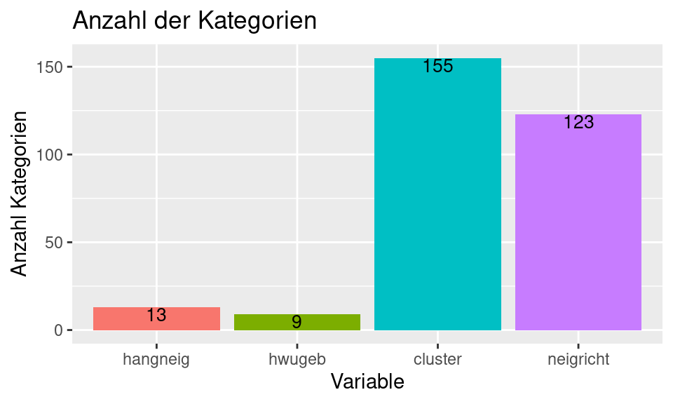

Figur 2: Anzahl Faktoren Kategorische Daten.

Es gibt somit insgesamt 300 Variablen die auf 286 Beobachtungen die fuer die Modellberechnung herangezogen werden. Liegen in einem Datensatz mehr Variablen als Beobachtungen vor, laesst sich ein lineares Regressionsmodell nicht mehr eindeutig schaetzen. Das lineare Regressionsmodell wird aufgrund seiner Bekanntheit, Interpretierbarkeit und Prognoseguete haeufig als Referenzmodell herangezogen. Da auch in dieser Arbeit ein lineares Regressionsmodell gescheatzt werden soll, muss fuer dieses eine weitere Variablenreduktion durchgefuehrt werden.

Die Entscheidung ueber die Reduktion einer kategorischen Variable soll durch eine ANOVA (Analysis Of Variance, Varianzanalyse) erfolgen. Kandidaten fuer die Variablenreduktion sind jene die von der ANOVA als nicht signifikant beurteilt werden.

|  | vorratha | gha | stzha | stzha_105 |
| --- | --- | --- | --- | --- |
| hwugeb | 0.000 | 0.076 | 0.065 | 0.139 |
| cluster | 0.014 | 0.098 | 0.256 | 0.438 |
| hangneig | 0.818 | 0.808 | 0.811 | 0.877 |
| neigricht | 0.202 | 0.410 | 0.879 | 0.782 |

Tabelle 14: ANOVA P-Werte Zusammenfassung.

Weiters ist zu beobachten dass fuer Stammzahl pro Hektar (Baeume ab 105mm Durchmesser) keine Variable signifikant ist.

## 3.3 Zusammenfassung Daten

In den Zielgroessen wie auch den erklaerenden Variablen konnten Ausreisser festgestellt werden. Ausreisser koennen die gemachten Modellschaetzungen verzerren. Es besteht die Moeglichkeit Ausreisser aus dem Datensatz zu entfernen. Aufgrund der hohen Dimensionalitaet in diesem Datensatz wuerde hierdurch die Schaetzung zusaetzlich noch ungenauer werden. Aus diesem Grund werden die Ausreisser fuer die weitere Analyse im Datensatz behalten.

Die Variablen maximale- und minimale Vegetationshoehe weisen starke Korrelationen mit der mittleren Vegetationshoehe und wurden aus diesem Grund aus der weiteren Analyse entfernt.

Aufgrund der hohen Dimensionalitaet der Daten kann ein lineares Regressionsmodell nicht mit diesen Daten geschaetzt werden. Zur weiteren Reduktion fuer dieses Modell wurde eine ANOVA der kategorischen Variablen durchgefuehrt. Es stellte sich herraus dass die Hangneigung und Neigerichtung fuer keine Zielvariable einen signifikanten Beitrag zur Erklaerung der Varianz beitragen. Somit werden diese fuer das lineare Regressionsmodell entfernt.

# 4 Methoden

Die Analyse der Daten besteht aus drei wesentlichen Komponenten: einem Modell, der Modellbewertung und der Software mit der die Berchnung durchgefuehrt wird. Im Folgenden wird auf die einzelnen Punkte genauer eingegangen.

## 4.1 Modelle

Die Modellierung der Daten erfolgt durch parametrische- und nichtparametrische Modelle. Neben der Auftailung in ein Trainings- und Testset wurden alle Modelle mit einer “ten fold crossvalidation” zehn (10) mal wiederholt geschaetzt.

### 4.1.1 Parametrische Modelle

Als parametrische Modelle werden geschaetzt:

- “Ordinary”: Least Squares (OLS) lineare Regressionsmodell
- “Penalized” Modelle: Ridge-, Lasso- und Elastic Net (EN) Modell
- “Feature Extraction” Modelle: Principal Component Regression (PCR) und Partial Least Squares (PLS)

In der Analyse ist somit ein (1) “ordinary-” (OLS), drei (3) “penalized-” und zwei (2) “feature extraction” Regressionsmodelle. Das OLS hat keine besonderen Umgang mit der hochen Dimensionalitaet der Daten. Aus diesem Grund mussten zusaetzliche kategorische Variablen aus dem Datensatz fuer dieses Modell entfernt werden. Die Idee hinter “penalized” Regressionsmodellen ist eine “Bestrafung” der Parameter die einen geringen Beitrag zur Erklaerung der Zielvariablen leisten. “Feature extraction” beruht hingegen auf der Idee Aehnlichkeiten (Korrelationen) der unabhaengigen Variablen auszunutzen um durch eine geeignete Projektion eine Reduktion der Dimensionalitaet zu erreichen. Nachteil dieses Verfahrens ist die Interpretierbarkeit. Da in dieser Arbeit rein die Prognosegute der Modelle verglichen wird ist die Intepretierbarkeit der parameter nicht weiter von Interesse.

### 4.1.2 Nichtparametrische Modelle

- K-Nearest Neighbour Modell (knn)
- Regression Tree (RTree)

“K-Nearest-Neighbours” Modelle beruhen auf der Annahme dass zwischen Daten die “nahe” zueinander liegen keine grossen Unterschiede zu erwarten ist. Die Naehe von Daten wird ueber eine Distanzfunktion berechnet, ueblich ist z.B. die Euklidische Distanzfuntion: $d(p, q) = \sqrt{q_1 -p_1)^2 + (q_2 - p_2)^2 + ... + (q_n - p_n)^2}$. Zu wievielen k- Daten die Distanz berechnet werden soll wird vom Anwender angegeben. Es gibt auch Methoden zur bestimmung des Optimalen “k” (z.B Ellbogen Methode). Der Regression Tree beruht auf der Idee die Daten durch sukzessive geeignete Trennungen zu unterteilen. Eine geeignete Trennung ist z.B. die Reduktion der Variabilitaet in den Daten.

## 4.2 Modellevaluierung

Der Modellvergleich erfolgt durch eine Quantifizierung der Prognoseguete eines Modells. Im ersten Schritt wird das Modell anhand der Trainingsdaten geschaetzt. Im zweiten Schritt wird anhand dem geschaetzten Modell und den uebrigen Testdaten eine Prognose gemacht. Diese Prognose wird im Folgenden mit den originalen Daten anhand folgender Formeln verglichen:

- Root Mean Squared Prediction Error (RMSPE): $\sqrt{\frac{\sum_{t=1}^T (\hat{y}_t - y_t)^2 }{T}}$, wobei $\hat{y}_t$ der Prognosewert und $y_t$ die tatsaechliche Beobachtung darstellt. Im Modellvergleich wird bei dieser Kennzahl das Modell mit dem geringeren Wert selektiert.
- $R^2$: $1 - \frac{\sum_{t=1}^T (y_t - \hat{y}_t)^2 }{\sum_{t=1}^T (y_t - \bar{y})^2}$, wobei $\hat{y}_t$ der Prognosewert und $\bar{y}$ den Mittelwert der Beobachtung darstellt. Im Modellvergleich wird bei dieser Kennzahl das Modell mit dem groesseren Wert selektiert.
- Mean Absolute Deviation (MAD): $\frac{\sum_{t=1}^T |y_t- \hat{y}_t|}{T}$. Im Modellvergleich wird bei dieser Kennzahl das Modell mit dem geringeren Wert selektiert.

Jede dieser Kennzahlen legt unterschiedliche Schwerpunkte. Aus diesem Grund werden alle drei Kennzahlen betrachtet. Ein Modell wird einem anderen bevorzugt wenn es is mindestens zwei (2) dieser Kennzahlen dem anderem Modell bevorzugt wird.

## 4.3 Software

Die gesamte Analyse wird mit der Software “R” durchgefuerht, konkret wird:

- ANOVA: bereits implementiert in R
- knn: R in Verbing mit (iVm) dem Packet “caret”
- Ridge, Lasso und Elastic Net: R iVm dem Packeten “caret” und “glmnet”
- PLS, PCR: R iVm dem Packeten “caret” und “glmnet”
- RTree: R iVm dem Packeten “caret” und “rpart”

# 5 Resultate

## 5.1 Vergleich Prognoseleistung

Tabelle 15 stellt die Uebersicht der Modellselektionskriterien fuer die Variable Stammholzvorrat pro Hektar (vorratha) dar. Aufgrund der Datenstruktur laesst sich das Elastic Net Modell nicht sinnvoll schaetzen. Vergleicht man die Selektionskriterien aller anderen Modelle laesst sich erkennen dass Lasso den geringsten RMSPE und MAD und den hoechsten $R^2$ hat. Somit ist Lasso eindeutig das beste Modell zur Prognose vom Stammholzvorrat pro Hektar unter allen getesteten Modellen.

|  | RMSE | Rsquared | MAE |
| --- | --- | --- | --- |
| OLS | 169.2482 | 0.4621246 | 132.8714 |
| Ridge | 208.5714 | 0.2910520 | 166.6473 |
| Lasso | 163.3645 | 0.4961033 | 127.8798 |
| EN | NA | 0.0104070 | NA |
| PCR | 171.5591 | 0.4448409 | 136.3586 |
| PLS | 166.9410 | 0.4731846 | 132.1550 |
| RTree | 187.5644 | 0.3357369 | 150.7952 |
| Knn | 180.1459 | 0.3861061 | 141.0877 |

Tabelle 15: Uebersicht der Modellseltionskriterien fuer die Stammholzvorrat pro Hektar.

Tabelle 16 stellt die Uebersicht der Modellselektionskriterien fuer die Variable Basalflaeche pro Hektar (gha) dar. Aufgrund der Datenstruktur laesst sich das Elastic Net Modell nicht sinnvoll schaetzen. Vergleicht man die Selektionskriterien aller anderen Modelle laesst sich erkennen dass Lasso den geringsten RMSPE und MAD und den hoechsten $R^2$ hat. Somit ist Lasso eindeutig das beste Modell zur Prognose von Basalflaeche pro Hektar unter allen getesteten Modellen.

|  | RMSE | Rsquared | MAE |
| --- | --- | --- | --- |
| OLS | 17.69816 | 0.1777709 | 14.31111 |
| Ridge | 18.65984 | 0.0624727 | 15.26453 |
| Lasso | 16.62040 | 0.2954426 | 13.91544 |
| EN | NA | 0.0414379 | NA |
| PCR | 17.10739 | 0.2164745 | 14.11103 |
| PLS | 17.09572 | 0.2195023 | 13.92646 |
| RTree | 18.36966 | 0.1145141 | 14.93000 |
| Knn | 17.51097 | 0.1759220 | 14.20199 |

Tabelle 16: Uebersicht der Modellseltionskriterien fuer die Basalflaeche pro Hektar.

Tabelle 17 stellt die Uebersicht der Modellselektionskriterien fuer die Variable Stammzahl pro Hektar (alle Baeume, stzha) dar. Aufgrund der Datenstruktur laesst sich das Elastic Net und Lasso Modell nicht sinnvoll schaetzen. Vergleicht man die Selektionskriterien aller anderen Modelle laesst sich erkennen dass OLS den geringsten RMSPE und MAD und den hoechsten $R^2$ hat. Somit ist OLS eindeutig das beste Modell zur Prognose von Stammzahl pro Hektar unter allen getesteten Modellen.

|  | RMSE | Rsquared | MAE |
| --- | --- | --- | --- |
| OLS | 883.9311 | 0.3098447 | 640.7119 |
| Ridge | 985.3157 | 0.1923138 | 745.0473 |
| Lasso | NA | 0.1739653 | NA |
| EN | NA | 0.0090701 | NA |
| PCR | 940.7734 | 0.2197125 | 685.4972 |
| PLS | 922.9949 | 0.2480693 | 671.2859 |
| RTree | 1057.1418 | 0.1374718 | 795.7521 |
| Knn | 1053.0809 | 0.0871058 | 774.2096 |

Tabelle 17: Uebersicht der Modellseltionskriterien fuer die Stammzahl pro Hektar.

Tabelle 18 stellt die Uebersicht der Modellselektionskriterien fuer die Variable Stammzahl pro Hektar (Baeume ab 105mm Durchmesser, stzha105) dar. Aufgrund der Datenstruktur laesst sich das Elastic Net nicht sinnvoll schaetzen. Vergleicht man die Selektionskriterien aller anderen Modelle laesst sich erkennen dass OLS den geringsten RMSPE und MAD und den hoechsten $R^2$ hat. Somit ist OLS eindeutig das beste Modell zur Prognose von Stammzahl pro Hektar (Baeume ab 105mm Durchmesser) unter allen getesteten Modellen.

|  | RMSE | Rsquared | MAE |
| --- | --- | --- | --- |
| OLS | 488.8611 | 0.2733215 | 394.1089 |
| Ridge | 536.5184 | 0.1650655 | 422.7854 |
| Lasso | 529.2087 | 0.1592085 | 416.0631 |
| EN | NA | 0.0006310 | NA |
| PCR | 510.9749 | 0.2394450 | 412.1338 |
| PLS | 497.0572 | 0.2635727 | 403.7022 |
| RTree | 525.4340 | 0.1674548 | 430.0552 |
| Knn | 537.9482 | 0.1237003 | 432.2051 |

Tabelle 18: Uebersicht der Modellseltionskriterien fuer die Stammzahl pro Hektar (Baeume ab 105mm Durchmesser).

## 5.2 Vergleich Erklaerungsgehalt

Aus den obigen Tabellen laesst sich vermuten dass Unterschiede in dem Erklaerungsgehalt der Modelle fuer die Unterschiedlichen abhaengigen Variablen vorliegen. Im folgenden wird durch eine ANOVA auf gleiche Mittelwerte des $R^2$ fuer die abhaengigen Variablen getestet:

```
##             Df Sum Sq Mean Sq F value   Pr(>F)
## Var2         3 0.2582 0.08608   16.85 4.19e-06 ***
## Residuals   24 0.1226 0.00511
## ---
## Signif. codes:  0 '***' 0.001 '**' 0.01 '*' 0.05 '.' 0.1 ' ' 1
```

Die Teststatistik ist hochsignifikant. Somit nehmen wir an dass sich die abhaengigen Variablen in ihrem Erklaerngsgehalt unterscheiden. Im Folgendem wird ein TukeyHSD Test durchgefuehrt, um festzustelle wo genau die Unterschiede liegen.

```
##   Tukey multiple comparisons of means
##     95% family-wise confidence level
##
## Fit: aov(formula = value ~ Var2, data = melt(df))
##
## $Var2
##                            diff         lwr        upr     p adj
## gha-vorratha       -0.232435610 -0.33782596 -0.1270453 0.0000157
## stzha-vorratha     -0.217237876 -0.32262823 -0.1118475 0.0000416
## stzha_105-vorratha -0.213911445 -0.31930180 -0.1085211 0.0000516
## stzha-gha           0.015197733 -0.09019262  0.1205881 0.9781820
## stzha_105-gha       0.018524164 -0.08686619  0.1239145 0.9617207
## stzha_105-stzha     0.003326431 -0.10206392  0.1087168 0.9997564
```

Wie man dem Test entnehmen kann unterscheidet sich der Erklaerungsgehalt der Variable “Stammholzvorrat pro Hektar” von allen anderen signifikant. Zwischen den anderen abhaengigen Variablen keine signifikanten Unterschiede im Erklaerungsgehalt vor.

# 6 Conclusio

Die Daten weisen markante Ausreisser auf. Aufgrund der hohen Dimensionalitaet der erklaerenden Variablen und der Aufteilung der Daten in ein Trainings- Testset wurde auf eine zusaetzliche Reduktion der Beobachtungen durch entfernen von Ausreissern verzichtet.

Es gibt deutliche Unterschiede im Erklaerungsgehalt der Modelle fuer die abhaengigen Variablen. “Stammholzvorrat pro Hektar” hat einen signifikant hoeheren Erklaerungsgehalt wie alle anderen abhaengigen Variablen. Allgemein ist der Erklaerungsgehlt fuer alle Variablen gering. Dies bedeutet dass kein Modell die Streuung in den abhaengigen Variablen gut erklaeren kann.

# Referenzen

Lefsky, Michael A, Warren B Cohen, Andrew Hudak, Steven A Acker, and J Ohmann. 1999. “Integration of Lidar, Landsat Etm+ and Forest Inventory Data for Regional Forest Mapping.” *International Archives of Photogrammetry and Remote Sensing* 32 (3/W14): 119–26.

McRoberts, Ronald E, Erkki O Tomppo, and Raymond L Czaplewski. n.d. “Sampling Designs for National Forest Assessments.”

Meng, Qingmin, Chris Cieszewski, and Marguerite Madden. 2009. “Large Area Forest Inventory Using Landsat Etm+: A Geostatistical Approach.” *ISPRS Journal of Photogrammetry and Remote Sensing* 64 (1): 27–36. https://doi.org/https://doi.org/10.1016/j.isprsjprs.2008.06.006.

Peterson, Birgit, Ralph Dubayah, Peter Hyde, Michelle Hofton, J Bryan Blair, and JoAnn Fites-Kaufman. 2007. “Use of Lidar for Forest Inventory and Forest Management Application.” In *In: McRoberts, Ronald E.; Reams, Gregory A.; van Deusen, Paul C.; Mcwilliams, William H., Eds. Proceedings of the Seventh Annual Forest Inventory and Analysis Symposium; October 3-6, 2005; Portland, Me. Gen. Tech. Rep. WO-77. Washington, Dc: US Department of Agriculture, Forest Service: 193-202.* Vol. 77.

Spurr, Stephen Hopkins. 1952. “Forest Inventory.”